# R Notebook

## Metadata

Required libraries and runtime environment description.

```r
library(emidata)
library(tidyverse)
library(tidytext)
```

This document is an EDA notebook to explore descriptive and informative figures of the dataset *papers* in the *emidata* package. Type `?papers` for information.

## Data

The data for the analysis is in the *papers* dataset that has `136` references.

```r
papers %>% str()
```

```
Classes ‘tbl_df’, ‘tbl’ and 'data.frame':   136 obs. of  9 variables:
 $ filename: chr  "004 - A Digital Tool to Promote Alcohol.pdf" "007 - A Guided Online and Mobile Self-Help.pdf" "008 - A Mindfulness Intervention for.pdf" "010 - A novel approach to challenging OCD.pdf" ...
 $ id      : chr  "004" "007" "008" "010" ...
 $ type    : chr  "Article" "Article" "Article" "Article" ...
 $ title   : chr  "A Digital Tool to Promote Alcohol and Drug Use Screening, Brief Intervention, and Referral to Treatment Skill T"| __truncated__ "A Guided Online and Mobile Self-Help Program for Individuals With Eating Disorders: An Iterative Engagement and"| __truncated__ "A Mindfulness Intervent…
 $ abstract: chr  "Background: Translation of knowledge and skills from classroom settings to clinical practice is a major challen"| __truncated__ "BACKGROUND: Numerous digital health interventions have been developed for mental health promotion and intervent"| __truncated__ "Physician burnout is a …
 $ journal : chr  "JMIR RESEARCH PROTOCOLS" "Journal of medical Internet research" "PEDIATRIC ANNALS" "Journal of Behavior Therapy and Experimental Psychiatry" ...
 $ author  : chr  "Derek D. Satre and Khanh Ly and Maria Wamsley and Alexa Curtis and Jason Satterfield" "M. Nitsch and C.N. Dimopoulos and E. Flaschberger and K. Saffran and J.F. Kruger and L. Garlock and D.E. Wilfle"| __truncated__ "Mallory Taylor and Joseph R. Hageman and Melanie Brown" "M. Ronce…
 $ year    : int  2017 2016 2016 2018 2017 2015 2016 2017 2018 2017 ...
 $ keywords: chr  "depression, anxiety, alcohol, drug, training, mobile app, digital health, implementation, SBIRT" "human, mobile application, telemedicine, questionnaire, Internet, Telemedicine, psychology, interview, Humans, "| __truncated__ NA "adult, anxiety assessment, Article, clinical effect…
```

As part of the text analysis of papers, including wordcloud and terms frequency analysis, read the full list of abstracts from the `papers` and process them to create a [tidy](https://www.jstatsoft.org/article/view/v059i10) data structure without [stop words](https://en.wikipedia.org/wiki/Stop_words).

```r
tidy_abstracts <- papers %>%
  select(id, filename, abstract) %>%
  arrange(id)
```

[output not shown]

*How many non-stop words does each abstract have?*

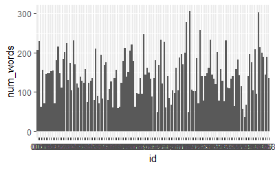

## Search terms in the abstract

### Psychological terms

The detection matches full words using regex option `\b`.

- mental (and also e-mental)
- psycholog (`psycholog.*`, i.e. psychology, psychological)
- psychiatric
- emotional
- health (and also e-health, u-health)
- treatment(s) (and also pretreatment, post-treatment)
- disorder(s)
- intervention(s)
- therapy(ies)
- distress,
- affection
- depressi (`depressi.*`, i.e. depression, depressive)
- anxiety,
- ecological momentary intervention

```r
term_counts <- tibble(
  id = tidy_abstracts$id,
  mental = stringr::str_count(tidy_abstracts_lower, "\\bmental\\b"),
  `psycholog..` = str_count(tidy_abstracts_lower, "\\bpsycholog.*\\b"),
  psychiatric = stringr::str_count(tidy_abstracts_lower, "\\bpsychiatric\\b"),
  emotional = stringr::str_count(tidy_abstracts_lower, "\\bemotional\\b"),
  health = stringr::str_count(tidy_abstracts_lower, "\\bhealth\\b"),
  `treatment(s)` = stringr::str_count(tidy_abstracts_lower, "\\btreatments?\\b|\\bpretreatment?\\b"),
  `disorder(s)` = stringr::str_count(tidy_abstracts_lower, "\\bdisorder?\\b"),
  `intervention(s)` = stringr::str_count(tidy_abstracts_lower, "\\bintervention?\\b"),
  `therapy/ies` = stringr::str_count(tidy_abstracts_lower, "\\btherap(y|ies)\\b"),
  distress = stringr::str_count(tidy_abstracts_lower, "\\bdistress\\b"),
  affection = stringr::str_count(tidy_abstracts_lower, "\\baffection\\b"),
  `depressi..` = str_count(tidy_abstracts_lower, "\\bdepressi.*\\b"),
  anxiety = stringr::str_count(tidy_abstracts_lower, "\\banxiety\\b"),
  emi = stringr::str_count(tidy_abstracts_lower, "\\becological momentary intervention\\b)"))
```

[output not shown]

*How often do psychological related search terms appear in each abstract?*

Psychological-related search terms in the corpus, ordered by sum of matches per asbtract

| id | mental | psycholog.. | psychiatric | emotional | health | treatment(s) | disorder(s) | intervention(s) | therapy/ies | distress | affection | depressi.. | anxiety | all |
| --- | --- | --- | --- | --- | --- | --- | --- | --- | --- | --- | --- | --- | --- | --- |
| 101 | 5 | 0 | 0 | 0 | 3 | 12 | 1 | 0 | 1 | 0 | 0 | 1 | 0 | 23 |
| 119 | 4 | 0 | 6 | 0 | 3 | 0 | 3 | 5 | 0 | 0 | 0 | 1 | 0 | 22 |
| 302 | 0 | 0 | 0 | 0 | 0 | 18 | 1 | 0 | 2 | 0 | 0 | 1 | 0 | 22 |
| 051 | 0 | 0 | 0 | 0 | 1 | 17 | 1 | 1 | 0 | 0 | 0 | 1 | 0 | 21 |
| 068 | 2 | 1 | 0 | 0 | 2 | 5 | 0 | 2 | 3 | 1 | 0 | 1 | 3 | 20 |
| 285 | 2 | 1 | 0 | 0 | 2 | 7 | 0 | 0 | 3 | 0 | 0 | 0 | 3 | 18 |
| 029 | 7 | 1 | 0 | 0 | 6 | 2 | 0 | 0 | 0 | 1 | 0 | 0 | 0 | 17 |
| 131 | 1 | 0 | 0 | 0 | 4 | 4 | 1 | 0 | 0 | 0 | 0 | 1 | 6 | 17 |
| 160 | 5 | 0 | 0 | 0 | 8 | 1 | 1 | 0 | 0 | 2 | 0 | 0 | 0 | 17 |
| 235 | 2 | 0 | 0 | 1 | 4 | 1 | 0 | 6 | 2 | 0 | 0 | 1 | 0 | 17 |
| 025 | 0 | 0 | 0 | 0 | 1 | 1 | 2 | 1 | 1 | 0 | 0 | 0 | 10 | 16 |
| 126 | 1 | 1 | 0 | 0 | 3 | 1 | 0 | 5 | 0 | 0 | 0 | 1 | 4 | 16 |
| 217 | 6 | 1 | 0 | 0 | 4 | 2 | 1 | 0 | 0 | 0 | 0 | 1 | 1 | 16 |
| 263 | 0 | 0 | 0 | 0 | 0 | 15 | 0 | 0 | 0 | 0 | 0 | 1 | 0 | 16 |
| 305 | 2 | 1 | 0 | 0 | 2 | 5 | 0 | 4 | 2 | 0 | 0 | 0 | 0 | 16 |
| 123 | 0 | 1 | 0 | 0 | 0 | 3 | 3 | 0 | 1 | 1 | 0 | 1 | 5 | 15 |
| 185 | 3 | 0 | 0 | 0 | 4 | 1 | 1 | 4 | 1 | 0 | 0 | 1 | 0 | 15 |
| 283 | 3 | 0 | 0 | 0 | 6 | 4 | 0 | 1 | 0 | 0 | 0 | 1 | 0 | 15 |
| 304 | 2 | 0 | 1 | 0 | 3 | 4 | 2 | 3 | 0 | 0 | 0 | 0 | 0 | 15 |
| 014 | 0 | 1 | 0 | 0 | 0 | 9 | 2 | 0 | 2 | 0 | 0 | 0 | 0 | 14 |
| 023 | 2 | 1 | 0 | 1 | 2 | 0 | 0 | 1 | 0 | 2 | 0 | 1 | 4 | 14 |
| 044 | 0 | 0 | 0 | 0 | 1 | 6 | 1 | 2 | 1 | 0 | 0 | 1 | 2 | 14 |
| 282 | 0 | 0 | 0 | 0 | 4 | 3 | 0 | 1 | 1 | 0 | 0 | 0 | 5 | 14 |
| 042 | 0 | 0 | 0 | 0 | 1 | 3 | 2 | 6 | 1 | 0 | 0 | 0 | 0 | 13 |
| 091 | 0 | 0 | 0 | 0 | 7 | 3 | 1 | 1 | 1 | 0 | 0 | 0 | 0 | 13 |
| 294 | 0 | 0 | 0 | 0 | 0 | 0 | 0 | 5 | 1 | 1 | 0 | 1 | 5 | 13 |
| 035 | 1 | 0 | 0 | 0 | 1 | 6 | 1 | 1 | 1 | 0 | 0 | 1 | 0 | 12 |
| 064 | 0 | 0 | 0 | 0 | 0 | 8 | 1 | 0 | 1 | 0 | 0 | 0 | 2 | 12 |
| 089 | 4 | 0 | 0 | 0 | 5 | 2 | 1 | 0 | 0 | 0 | 0 | 0 | 0 | 12 |
| 177 | 0 | 0 | 0 | 0 | 3 | 1 | 0 | 7 | 1 | 0 | 0 | 0 | 0 | 12 |

[output cut: 107 more lines]

### Technical terms

*Search terms*: cell, mobile smartphone, smart, portable, phone*, device*, app, apps, applicat*, mhealth, uhealth, ehealth, emental, android, iphone